# Lab 9: Regression and basic (discrete) approximation theory

### 1d Outliers

The $y_1$ entry (if we count starting at the index $0$) should be 4.7. Suppose the data comes from a person typing it in, and they typed in "7.4" rather than "4.7". We call this an "outlier".

**Task**: using the same $x$ values as above, and the $y$ values provided below, run $\ell_p$ regression for $p=1,2,\infty$ and decide which choice of $p$ makes the most sense. Justify this with a sentence of text. You should make a plot to help arrive at your conclusion.

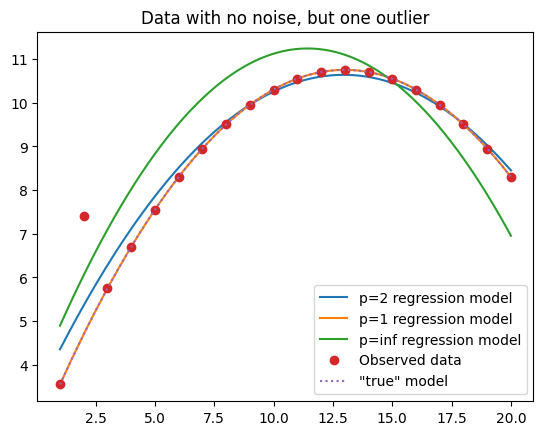

```python
y   = trueModel(x)
# y[1] is supposed to be 4.7, but suppose we typed it in as a 7.4
y[1] = 7.4

# ... add your own code below, make a plot, and write a sentence or two about the results
for p in [2,1,"inf"]:
    poly = lp_regression(x,y,deg,p=p)
    plt.plot(xPlot,poly(xPlot),'-', label=f'p={p} regression model')
plt.plot(x,y,'o', label='Observed data')
plt.plot(xPlot,trueModel(xPlot),':', label='"true" model')
plt.legend()
plt.title('Data with no noise, but one outlier')
plt.show()

# The p=1 model is completely accurate as it is not affected by the outlier at all,
# whereas the p=inf model is pulled up by the outlier, and the p=2 model is pulled up on the left and right side,
# and the parabola is shorter than it needs to be.
```

### 1e Different weights

Suppose the variance of our noise depends on which $x_i$ variable we're looking at. For example, you and your lab partner take turns collecting data, and you're a much better experimentalist than your lab partner.

Below, we'll use the `std` variable to control the standard deviation of each noise entry.

Do this for **one** choice of $p$, but compare weighted vs unweighted regression. Does weighted regression work significantly better, or is there little difference? (or does it work worse? double-check your implementation)

**Task**: using the same $x$ values as above, the $y$ values provided below, and the correct weights (hint: we want to weight observations with more variance *less* than observations with less variance), run $\ell_p$ regression for a choice of $p$ decide if weighted regression is better or worse than unweighted regression. Justify this with a sentence of text. You should make a plot to help arrive at your conclusion.

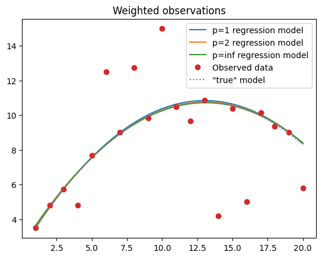

```python
rng = np.random.default_rng(67)
std = np.tile( [.1,5], int(m/2) )
y   = trueModel(x) + std*rng.standard_normal(m)

# ... add your own code below, make a plot, and write a sentence or two about the results
# Given the "std" vector, how should you define your weights vector?
for p in [1,2,"inf"]:
    poly = lp_regression(x, y, deg, p=p, weights=np.array([1/i for i in std]))
    plt.plot(xPlot,poly(xPlot),'-', label=f'p={p} regression model')
plt.plot(x,y,'o', label='Observed data')
plt.plot(xPlot,trueModel(xPlot),':', label='"true" model')
plt.legend()
plt.title('Weighted observations')
plt.show()

# Since the standard devidations give us how far off our data may or may not be,
# we want to multiply by the inverse of the standard deviation to give the correct
# weight. This gives very close approximations of the 'true' model!
```

## Part 2: real world data

Task: find any dataset on the internet that you want, and do a regression fit to it. You need to decide:

1. which dataset (and any **transformations** to do, e.g., take the log()??)
2. what degree polynomial to fit
3. what kind of loss: l2 (a good default choice), or something fancier?

If you need ideas of where to browse for a dataset, try:

- [UCI Machine Learning Repository](https://archive.ics.uci.edu/datasets)
- [PyTorch datasets](https://docs.pytorch.org/vision/main/datasets.html)
- [Kaggle datasets](https://www.kaggle.com/datasets)
- [Google dataset search](https://datasetsearch.research.google.com/)
- [Hugging face datasets](https://huggingface.co/docs/datasets/en/index)
- Weather data, since there are many nice python wrappers to download this, e.g., meteostat-python
- Financial data, also lots of nice python wrappers. For financial data, does it make sense to take the log() or not?

You're not restricted to time series data, but they are particularly simple since there's a single scalar independent variable (which is the case we've covered), so I recommend them

**Task**: run a regression and create a plot showing the data and the regression curve. Add a sentence or two about your decision making (what degree polynomial? Did you preprocess data? which value of $p=1,2,\infty$ made the most sense?).

```python
#import yfinance as yf # just an example (this is an API for Yahoo Finance)
import numpy as np
```

```python
# ... add your own code below, make a plot, and write a sentence or two about the results
# Temperature data for Boulder obtained from https://psl.noaa.gov/boulder/getdata.html
data = np.genfromtxt(
    "Data/boulder_weather.txt",
    comments="#",
    usecols=(0,1,2,3,4),
    invalid_raise=False
)

year  = data[:,0].astype(int)
month = data[:,1].astype(int)
day   = data[:,2].astype(int)
tmax  = data[:,3]
tmin  = data[:,4]

mask = (year == 2026) & (month == 2)

feb_days = day[mask]
feb_tmax = tmax[mask]


result = np.column_stack((feb_days, feb_tmax))
```

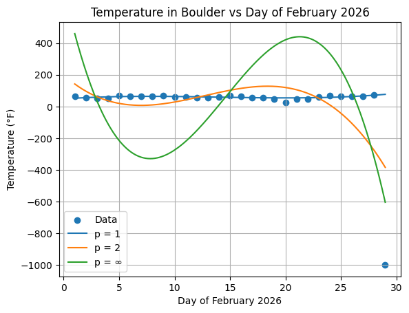

```python
import numpy as np
import matplotlib.pyplot as plt

deg = 3

# Fit models
poly_p1  = lp_regression(feb_days, feb_tmax, deg, p=1)
poly_p2  = lp_regression(feb_days, feb_tmax, deg, p=2)
poly_pinf = lp_regression(feb_days, feb_tmax, deg, p=np.inf)

# Smooth x grid for plotting
x_plot = np.linspace(min(feb_days), max(feb_days), 400)

# Evaluate models
y_p1 = poly_p1(x_plot)
y_p2 = poly_p2(x_plot)
y_pinf = poly_pinf(x_plot)

# Plot
plt.figure()

plt.scatter(feb_days, feb_tmax, label="Data")

plt.plot(x_plot, y_p1, label="p = 1")
plt.plot(x_plot, y_p2, label="p = 2")
plt.plot(x_plot, y_pinf, label="p = ∞")

plt.xlabel("Day of February 2026")
plt.ylabel("Temperature (°F)")
plt.title("Temperature in Boulder vs Day of February 2026")
plt.legend()
plt.grid()

plt.show()

# Note that the outlier on the 29th (not a day this year)
# has a huge effect on p=2 and p=inf but no effect on
# p = 1! The p=2 and p=inf models are not very good fits, and
# certainly not good for extrapolatoin.
```

## Part 3: for the ambitious, try Orthogonal Distance Regression

Look into ODR (or it's linear version, [total least squares](https://en.wikipedia.org/wiki/Total_least_squares)) using `scipy.odr`

```python
# Basic TLS is simple and just requires an SVD. Let's download some code we found on the internet:
!wget -q https://github.com/RyotaBannai/total-least-squares/raw/refs/heads/master/tsl.py
from tsl import tls
```

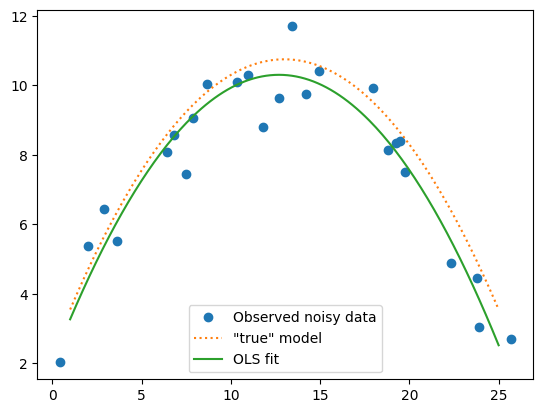

```python
from scipy import odr
import numpy as np

m   = 25 # number of data points
a, b = 1, m # x domain
x   = np.linspace(a,b,m) # nodes
trueModel = lambda x : 2.3 + 1.3*x - .05*x**2
deg = 2 # we'll try to fit the data with a degree 2 polynomial
rng   = np.random.default_rng(67)

# Error in variables and in responses
xx = x + rng.standard_normal(m)
y = trueModel( xx ) + rng.standard_normal(m)
plt.plot(xx,y,'o', label='Observed noisy data')
xPlot = np.linspace(a,b,200) # for plotting only
plt.plot(xPlot,trueModel(xPlot),':', label='"true" model')

# Re-use our code to give us the Vandermonde matrix
poly, coeff, X, poly_from_coeffs = lp_regression(x,y,deg=2,p=2,debug=True)
plt.plot(xPlot,poly(xPlot),label='OLS fit')


# ... add your own code below, make a plot, and write a sentence or two about the results
# ... Try calling the tls() code (give it your Vandermonde matrix and response y)
# and/or, try the ODR package from scipy, e.g., data = odr.Data(x, y), ...

plt.legend()
plt.show()
```